# Trees

ML

16 January 2019

# EXERCISES - PHYLOGENETIC TREES FOR META-ANALYSIS

Prepared by Malgorzata (Losia) Lagisz, BEES, UNSW, AU, losialagisz@gmail.com

**Setup:** Work can be done individually, in pairs or small groups. R/Rstudio and Internet connection needed.

## Introduction

Ecological and evolutionary meta-analyses usually aggregate data across multiple species (there are single-species or non-species meta analyses too, but these are minority). Since species are related due to shared evolutionary history, effect sizes of closely related species can be more similar to these of less-related species. This kind of non-independence can be represented as a correlation matrix of phylogenetic relatedness and added as a random factor to multilevel meta-analytic models. To create a relatedness matrix among species we need a phylogenetic tree for the list of species from our data set.

A few things to note:  
1. We can use a tree with or without branch lengths (divergence measures) although we do need branch lengths for analysis (often making certain assumptions).

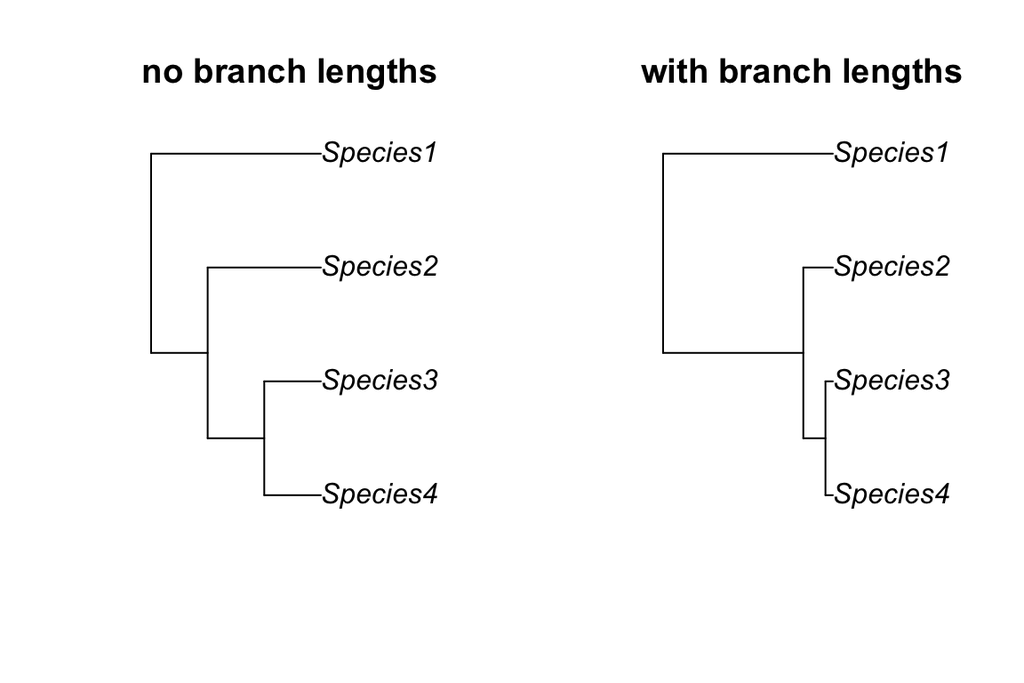

2. The tree has to be binary (strictly bifurcating = no polytomies, i.e. only two branches are coming from each node). Here is a simple example:

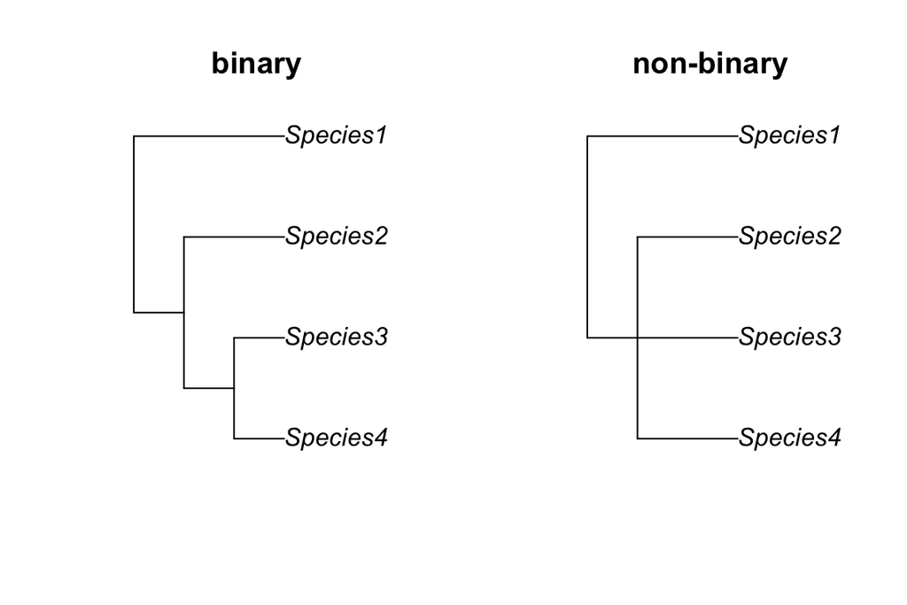

3. The tree needs to be rooted (has a node representing the most recent common ancestor of all the species in the tree).

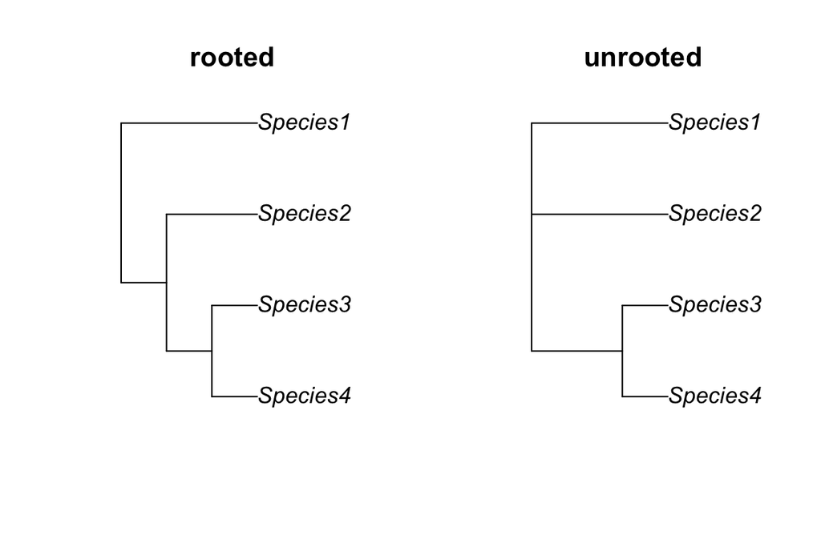

4. The tree tip labels (representing species) must match **exactly** with the species names in the data set (otherwise MA models will not run with them).

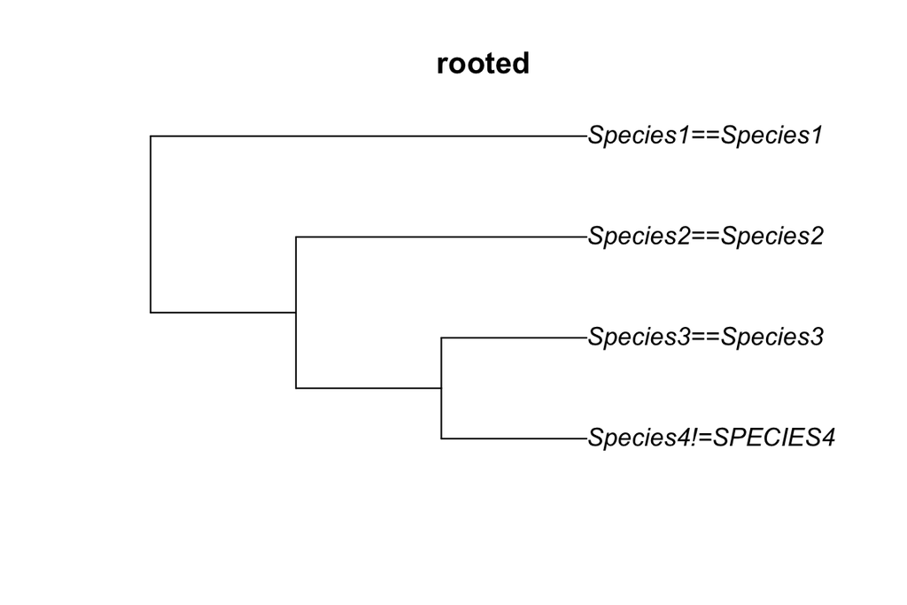

5. Trees can be also made and used for higher taxonomic levels than species, e.g. genus-level (not covered in this tutorial, but general principles are the same).

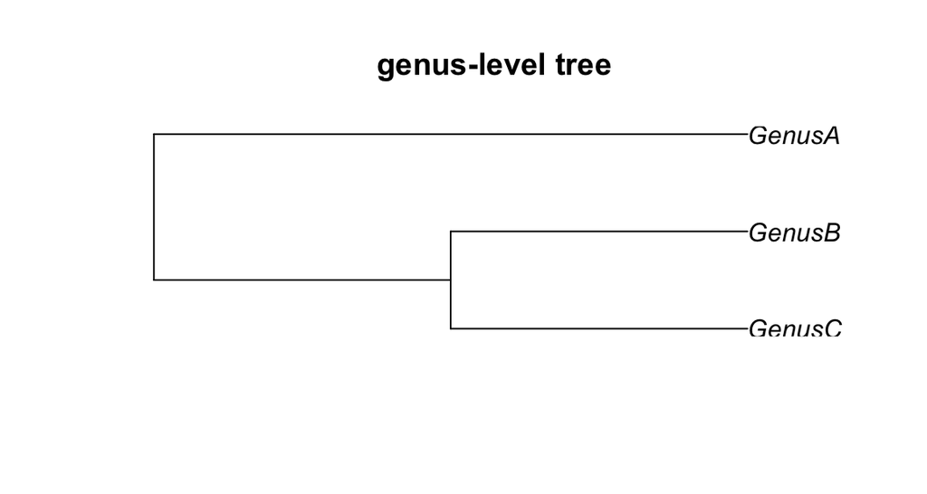

The general flow of tree-making work is shown in the diagram below.  
You will usually start with species list from the meta-analytic data set (use binomial Latin names for the species list and in your database). First, check if there is any phylogenetic tree available that already contains all your species (e.g. a super-tree). Currently, the easiest way to build a custom phylogenetic tree usable for meta-analysis is by using an R package called *rotl*, which accesses a synthetic super-tree from Open Tree of Life database (https:// opentreeoflife.org). We will use this approach in our examples below. Most of the time *rotl* will work well, especially with the common species. There are other super-trees available, e.g. for birds - we will use one of these as our example too. Overall, if you can find a tree that contains all your species, you just trim (subset) it down to your species. If a few species is missing, it is sometimes possible to substitute them with closely related species. If no existing phylogeny is readily usable, there are a few non-exclusive options depending on the range of species in the data set:  
- If the species are very diverged (e.g. mixture of vertebrates and invertebrates), use NCBI Taxonomy Common Tree tool (http://www.ncbi.nlm.nih.gov/Taxonomy/CommonTree/wwwcmt.cgi). At the webpage, use an input box at the top of the page to search each species name or upload list of the species names from a file. This allows to generate a scaffold for a tree (i.e. the pattern of basal branching for the main clades).  
- If few major clades are present, assemble together sub-trees created from bigger trees, if these exist for these clades.  
- Use phyloGenerator (http://willpearse.github.io/phyloGenerator/) or other phylogenetic software to create phylogeny based on DNA sequences, if a shared sequence set exists for a given set of species (check if the resulting phylogeny makes sense).

If the resulting tree contains polytomies, these can be resolved at random, or based on information from more detailed trees (e.g. published phylogenies of specific lower taxa). You can also graft missing species on your tree. Be aware of species names problems: typos, scientific name synonyms, subspecies - have to be re-checked / corrected / substituted if generate errors at any stage. Again, your final tree, must contain exactly the same list of species names as your meta-analytic data set.

Run the below code chunks IF you have not installed these packages earlier (it may take 15-20 minutes to install all).

```r
install.packages("metafor")
install.packages("diagram")
install.packages("tidyverse")
install.packages("ape")
install.packages("curl")
install.packages("fulltext")
install.packages("treebase")
install.packages("devtools")
devtools::install_github("ropensci/rotl", dependencies = TRUE, build_vignette=TRUE)
install.packages("rotl")
```

```r
library(diagram, tidyverse)
library(ape, curl)
library(fulltext, metafor)
library(treebase, devtools)
library(rotl)
```

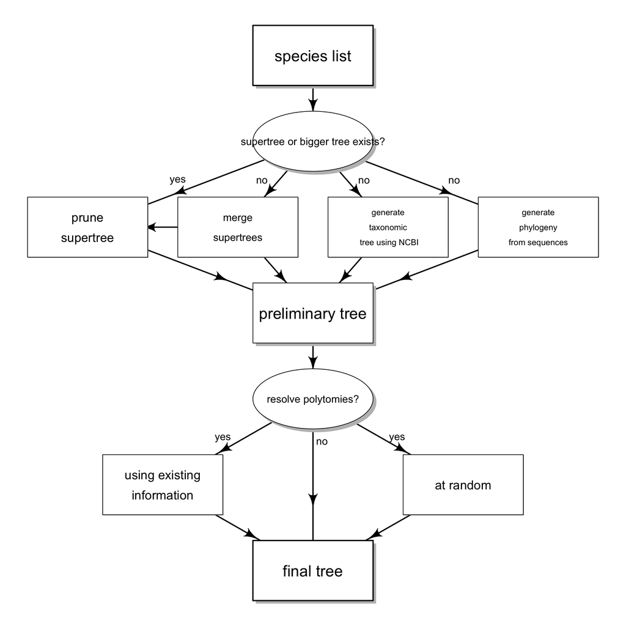

## Examples and exercises

We will give you some examples on how to use *rotl* package to download sub-trees from the Open Tree of Life super-tree, resolve polytomies, trim and plot trees and deal with some of the most common issues. We will try to do most of theses tasks in R, but doing many of these outside R (using websites, text and tree editors, etc.) is also possible. We hope you get the idea of the main principles of the process.

Now, we start from installing (as required) and loading R packages we will use.

### EXAMPLE 1 - using *rotl* package

We will try to create a simple tree using 10 commonly used taxa (lab model species) from across the tree of life.  
Rotl is an R package (https://peerj.com/preprints/1471/) allowing us to access synthetic phylogenetic tree available at Open Tree of Life database (https:// opentreeoflife.org/).

**Important**: use Latin names, not common names.  
**Notes**: *rotl* crashes on some species lists. Also, Open Tree of Life database gets constantly updated with new info, so you can get different outputs at different time-points.

We use a function *tnrs_match_names*, which returns a data frame that lists the Open Tree identifiers potentially matching our species.  
The function also returns other information, including alternative species names, to help users ensure that the taxa matched are the correct ones.

```r
myspecies <- c("Escherichia colli",
               "Chlamydomonas reinhardtii",
               "Drosophila melanogaster",
               "Arabidopsis thaliana",
               "Rattus norvegicus",
               "Mus musculus",
               "Cavia porcellus",
               "Xenopus laevis",
               "Saccharomyces cervisae",
               "Danio rerio")
taxa <- tnrs_match_names(names = myspecies)
taxa
```

```
##                search_string               unique_name approximate_match
## 1          escherichia colli          Escherichia coli              TRUE
## 2  chlamydomonas reinhardtii Chlamydomonas reinhardtii             FALSE
## 3    drosophila melanogaster   Drosophila melanogaster             FALSE
## 4       arabidopsis thaliana      Arabidopsis thaliana             FALSE
## 5          rattus norvegicus         Rattus norvegicus             FALSE
## 6               mus musculus              Mus musculus             FALSE
## 7            cavia porcellus           Cavia porcellus             FALSE
## 8             xenopus laevis            Xenopus laevis             FALSE
## 9     saccharomyces cervisae  Saccharomyces cerevisiae              TRUE
## 10               danio rerio               Danio rerio             FALSE
##     ott_id is_synonym          flags number_matches
## 1   474506      FALSE SIBLING_HIGHER              6
## 2    33153      FALSE                             1
## 3   505714      FALSE                             1
## 4   309263      FALSE                             1
## 5   271555      FALSE                             1
## 6   542509      FALSE                             1
## 7   744000      FALSE                             1
## 8   465096      FALSE                             1
## 9   356221      FALSE                             7
## 10 1005914      FALSE                             1
```

Note that two of the species names in our list have typos, and are labelled TRUE in a column “approximate_match”. Still, they were matched to correct species names.  
If typos are detected, it is worth correcting the names in the original data set and re-running tree search.

```r
myspecies_fixed <- c("Escherichia coli",
               "Chlamydomonas reinhardtii",
               "Drosophila melanogaster",
               "Arabidopsis thaliana",
               "Rattus norvegicus",
               "Mus musculus",
               "Cavia porcellus",
               "Xenopus laevis",
               "Saccharomyces cerevisiae",
               "Danio rerio")
taxa <- tnrs_match_names(names = myspecies_fixed)
taxa
```

```
##                search_string               unique_name approximate_match
## 1           escherichia coli          Escherichia coli             FALSE
## 2  chlamydomonas reinhardtii Chlamydomonas reinhardtii             FALSE
## 3    drosophila melanogaster   Drosophila melanogaster             FALSE
## 4       arabidopsis thaliana      Arabidopsis thaliana             FALSE
## 5          rattus norvegicus         Rattus norvegicus             FALSE
## 6               mus musculus              Mus musculus             FALSE
## 7            cavia porcellus           Cavia porcellus             FALSE
## 8             xenopus laevis            Xenopus laevis             FALSE
## 9   saccharomyces cerevisiae  Saccharomyces cerevisiae             FALSE
## 10               danio rerio               Danio rerio             FALSE
##     ott_id is_synonym          flags number_matches
## 1   474506      FALSE SIBLING_HIGHER              1
## 2    33153      FALSE                             1
## 3   505714      FALSE                             1
## 4   309263      FALSE                             1
## 5   271555      FALSE                             1
## 6   542509      FALSE                             1
## 7   744000      FALSE                             1
## 8   465096      FALSE                             1
## 9   356221      FALSE                             1
## 10 1005914      FALSE                             1
```

When we are happy with the taxa found Open Tree identifiers, we can pass them to the function tol_induced_subtree to retrieve the relationships among these taxa (a trimmed sub-tree from the synthetic phylogenetic tree).

```r
tree <- tol_induced_subtree(ott_ids = taxa[["ott_id"]], label_format = "name") #we can get a Warning meassage here about collapsing single nodes
```

The tree is returned as an ape::phylo object and it can be manipulated, printed and saved easily using functions from the ape package.

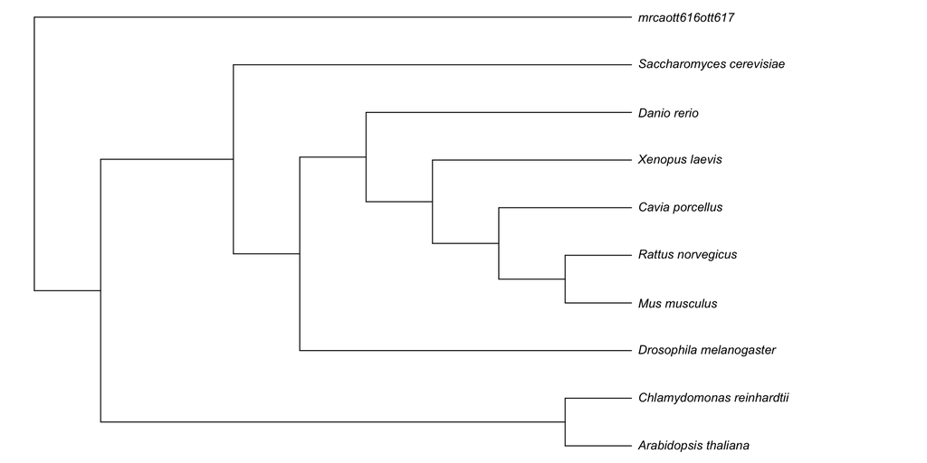

```r
plot(tree, cex=.8, label.offset =.1, no.margin = TRUE)
```

```r
tree$tip.label #see the current tree tip labels
```

```
##  [1] "Arabidopsis_thaliana"      "Chlamydomonas_reinhardtii"
##  [3] "Drosophila_melanogaster"   "Mus_musculus"
##  [5] "Rattus_norvegicus"         "Cavia_porcellus"
##  [7] "Xenopus_laevis"            "Danio_rerio"
##  [9] "Saccharomyces_cerevisiae"  "mrcaott616ott617"
```

```r
ecoli <- tol_node_info(ott_id=474506, include_lineage=TRUE)
tax_lineage(ecoli) #domain within Bacteria
```

```
##      rank               name        unique_name ott_id
## 1  domain           Bacteria           Bacteria 844192
## 2 no rank cellular organisms cellular organisms  93302
```

```r
tnrs_match_names(names = ("Escherichia")) #we can see what info is available for this genus - not much, ooks like a messy bit of a tree flagged as "INCONSISTENT"
```

```
##   search_string unique_name approximate_match ott_id is_synonym
## 1   escherichia Escherichia             FALSE 474503      FALSE
##                  flags number_matches
## 1 BARREN, INCONSISTENT              1
```

```r
tree$tip.label <- gsub("mrcaott616ott617", "Escherichia coli", tree$tip.label) #replace the tip label back with our species name
tree$tip.label <- gsub("_"," ", tree$tip.label) #get rid of the underscores
```

It is time to plot and tidy up the tree (note no branch lengths are included, they can be created later via simulations).

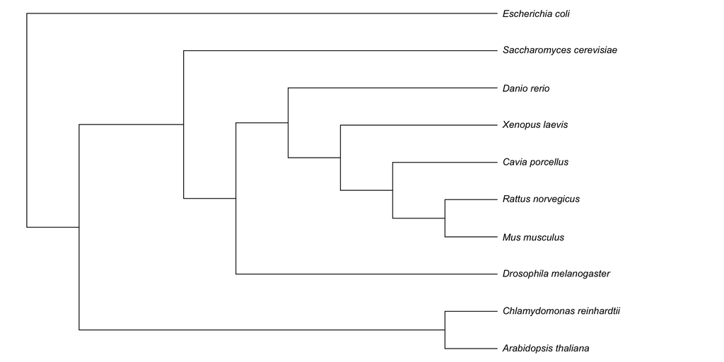

```r
# tree #see the tree info
# tree$node.label <- NULL #you can delete internal node labels
plot(tree, cex=.8, label.offset =.1, no.margin = TRUE) #plot the tree
```

Do a final check whether the tree is binary and if the tip labels of the tree match exactly our (fixed for typos) list of species.

```r
#check if the tree is really binary
is.binary.tree(tree) #TRUE (i.e. there are no polytomies)
```

```
## [1] TRUE
```

```r
#check the overlap between the species names from the data set (our species list) nad the final tree
intersect(as.character(tree$tip.label), myspecies_fixed) #10 matching names
```

```
##  [1] "Arabidopsis thaliana"      "Chlamydomonas reinhardtii"
##  [3] "Drosophila melanogaster"   "Mus musculus"
##  [5] "Rattus norvegicus"         "Cavia porcellus"
##  [7] "Xenopus laevis"            "Danio rerio"
##  [9] "Saccharomyces cerevisiae"  "Escherichia coli"
```

```r
setdiff(myspecies_fixed, as.character(tree$tip.label)) #0 mismatches
```

```
## character(0)
```

```r
setdiff(as.character(tree$tip.label), myspecies_fixed) #0 mismatches
```

```
## character(0)
```

That was hopefully easy! We can move to a different set of species and method…

### EXAMPLE 2 - using a supertree from a file

There are a few main existing and established super-trees for birds, so they can be used to create a sub-tree containing only the species from the list.  
Here we will use on of these super-trees called “Ericson backbone”, which is downloadable from http://birdtree.org/ (Jetz, W., G. H. Thomas, J. B. Joy, K. Hartmann, and A. O. Mooers. 2012. The global diversity of birds in space and time. Nature 491:444-448.). The website http://birdtree.org/ also has an online tool for subsetting their super-trees generating distribution of trees rather than one tree. For simplicity and demonstration purposes we will use R to subset (prune) a single bird super-tree down to a smaller list of species.

We have our custom list of bird species stored in a file *bird_list.csv* as a simple string factor and we have downloaded Ercison tree stored in a file *Ericson.tre*, in Newick format with branch lengths included. Load these files and check the species overlap.

```r
birds <- unique(read.csv("../data/bird_list.csv")$species_name) #load our list of bird species and make the names unique
birds_stree <- read.tree("../data/Ericson.tre") #load bird supertree
birds_stree #9993 tips = species
```

```
##
## Phylogenetic tree with 9993 tips and 9992 internal nodes.
##
## Tip labels:
##  Taoniscus_nanus, Eudromia_formosa, Eudromia_elegans, Tinamotis_pentlandii, Tinamotis_ingoufi, Nothura_boraquira, ...
##
## Rooted; includes branch lengths.
```

```r
# str(birds_stree) # ypu can see this tree has edge (branch) lengths

###check the overlap between species name from our list  and the bird supertree
intersect(as.character(birds_stree$tip.label), birds) #51 - all our species matching - they are contained in the tree
```

```
##  [1] "Anseranas_semipalmata"         "Chen_caerulescens"
##  [3] "Branta_canadensis"             "Aythya_ferina"
##  [5] "Aythya_affinis"                "Aythya_fuligula"
##  [7] "Centrocercus_urophasianus"     "Phasianus_colchicus"
##  [9] "Gallus_gallus"                 "Pavo_cristatus"
## [11] "Columba_livia"                 "Phoebastria_irrorata"
## [13] "Sula_nebouxii"                 "Pygoscelis_antarcticus"
## [15] "Eudyptes_chrysocome"           "Vanellus_vanellus"
## [17] "Philomachus_pugnax"            "Sterna_hirundo"
## [19] "Sterna_dougallii"              "Larus_delawarensis"
## [21] "Larus_argentatus"              "Larus_michahellis"
## [23] "Larus_fuscus"                  "Larus_ridibundus"
## [25] "Stercorarius_parasiticus"      "Cuculus_canorus"
## [27] "Corvus_monedula"               "Corvus_corone"
## [29] "Pica_pica"                     "Parus_caeruleus"
## [31] "Cincloramphus_cruralis"        "Delichon_urbicum"
## [33] "Sturnus_unicolor"              "Sturnus_vulgaris"
## [35] "Turdus_merula"                 "Luscinia_svecica"
## [37] "Ficedula_albicollis"           "Passer_domesticus"
## [39] "Carpodacus_mexicanus"          "Serinus_canaria"
## [41] "Zonotrichia_leucophrys"        "Molothrus_bonariensis"
## [43] "Agelaius_phoeniceus"           "Quiscalus_mexicanus"
## [45] "Quiscalus_major"               "Xanthocephalus_xanthocephalus"
## [47] "Erythrura_gouldiae"            "Taeniopygia_guttata"
## [49] "Lonchura_striata"              "Falco_sparverius"
## [51] "Falco_tinnunculus"
```

```r
setdiff(birds, as.character(birds_stree$tip.label)) #0 mismatches - just making sure we have all our species included in the supertree, if you get any mismatches here look for typos or name synonyms!
```

```
## character(0)
```

Prune super-tree tree to a list of taxa from our list.

```r
pruned_birds_stree <- drop.tip(birds_stree,birds_stree$tip.label[-match(birds, birds_stree$tip.label)]) #pruning
#check the pruned tree
is.binary.tree(pruned_birds_stree) #TRUE
```

```
## [1] TRUE
```

```r
is.ultrametric(pruned_birds_stree) #TRUE
```

```
## [1] TRUE
```

```r
has.singles(pruned_birds_stree) #check for singles - the single nodes (i.e., with a single descendant) in a tree
```

```
## [1] FALSE
```

```r
# pruned_birds_stree <- collapse.singles(pruned_birds_stree) #if singles are preset, you can clean them up using collapse.singles function

# intersect(as.character(pruned_birds_stree$tip.label), birds) #51 - all our species matching - they are contained in the tree
setdiff(birds, as.character(pruned_birds_stree$tip.label)) #0 mismatches - just making sure we have all our species included in the tree
```

```
## character(0)
```

```r
# write.tree(pruned_birds_stree, file = "birds_51sp_tree.tre", append = FALSE, digits = 10, tree.names = FALSE) #save, if needed
```

Plot the tree.

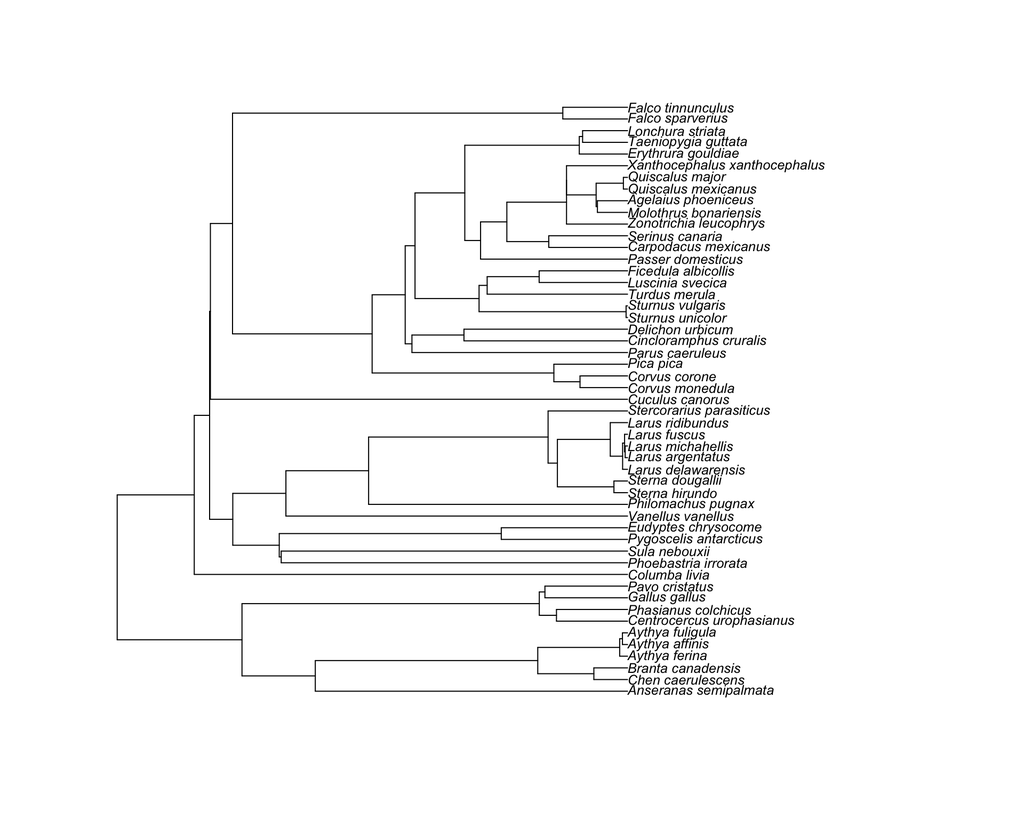

```r
plot(pruned_birds_stree, cex=0.8) #plots with branch lengths when available
```

**Notes**: We were lucky that all our species had matches on the super-tree. Quite often there are no matches for some of the species names. In such cases, first check the names for typos or unnecessary characters, then try to find synonymous names and check if these are included in the super-tree. Finally, a sister species can be used when a species is truly missing. Remember to match the names on the final tree back to the original species list from the data set.

### EXAMPLE 3 - using *rotl* package again

We will now handle a larger set of more closely related taxa, from a real data set.  
The data set we use the data set *dat.curtis1998* (contains studies on the Effects of Elevated CO2 Levels on Woody Plant Mass) included in the *metafor* package.

```r
dat <- metafor::dat.curtis1998
str(dat) #102 rows, many columns including various data
```

```
## 'data.frame':    102 obs. of  20 variables:
##  $ id      : int  21 22 27 32 35 38 44 63 86 87 ...
##  $ paper   : int  44 44 121 121 121 121 159 183 209 209 ...
##  $ genus   : chr  "ALNUS" "ALNUS" "ACER" "QUERCUS" ...
##  $ species : chr  "RUBRA" "RUBRA" "RUBRUM" "PRINUS" ...
##  $ fungrp  : chr  "N2FIX" "N2FIX" "ANGIO" "ANGIO" ...
##  $ co2.ambi: num  350 350 350 350 350 350 350 395 350 350 ...
##  $ co2.elev: num  650 650 700 700 700 700 700 795 700 700 ...
##  $ units   : chr  "ul/l" "ul/l" "ppm" "ppm" ...
##  $ time    : int  47 47 59 70 64 50 730 365 365 365 ...
##  $ pot     : chr  "0.5" "0.5" "2.6" "2.6" ...
##  $ method  : chr  "GC" "GC" "GH" "GH" ...
##  $ stock   : chr  "SEED" "SEED" "SEED" "SEED" ...
##  $ xtrt    : chr  "FERT" "FERT" "NONE" "NONE" ...
##  $ level   : chr  "HIGH" "CONTROL" "." "." ...
##  $ m1i     : num  6.82 2.6 2.99 5.91 4.61 ...
##  $ sd1i    : num  1.77 0.667 0.856 1.742 1.407 ...
##  $ n1i     : int  3 5 5 5 4 5 3 3 20 16 ...
##  $ m2i     : num  3.94 2.25 1.93 6.62 4.1 ...
##  $ sd2i    : num  1.116 0.328 0.552 1.631 1.257 ...
##  $ n2i     : int  5 5 5 5 4 3 3 3 20 16 ...
```

Extract and clean the list of species included. Note that genus and species name are stored in separate columns. Also, same species name can appear several times in the data set, but since we need a species list, we need each name to appear only once (i.e. unique names), and capitalisation to be consistent (letter case matters when matching strings).

```r
species_Curtis1998 <- paste(dat$genus, dat$species, sep=" ")
# str(species_Curtis1998)
species_Curtis1998 <- unique(tolower(species_Curtis1998)) #make species name unique
length(species_Curtis1998) #37
```

```
## [1] 37
```

```r
species_Curtis1998 #note: "populusx euramericana" should be same as "populus euramericana"
```

```
##  [1] "alnus rubra"             "acer rubrum"
##  [3] "quercus prinus"          "malus domestica"
##  [5] "acer saccharinum"        "castanea sativa"
##  [7] "citrus sinensis"         "pinus radiata"
##  [9] "nothofagus fusca"        "pseudotsuga menziesii"
## [11] "pinus echinata"          "quercus alba"
## [13] "liriodendron tulipifera" "betula pendula"
## [15] "picea abies"             "piper auritum"
## [17] "senna multijuga"         "myriocarpa longipes"
## [19] "cecropia obtusifolia"    "trichospermum mexicanum"
## [21] "betula lenta"            "betula papyrifera"
## [23] "betula populifolia"      "betula alleghaniensis"
## [25] "pinus banksiana"         "betula pubescens"
## [27] "pinus ponderosa"         "quercus rubra"
## [29] "acer pensylvanicum"      "fraxinus americana"
## [31] "populusx euramericana"   "picea mariana"
## [33] "picea glauca"            "populus euramericana"
## [35] "maranthes corymbosa"     "acer saccharum"
## [37] "populus tremuloides"
```

```r
species_Curtis1998 <- gsub("populusx euramericana", "populus euramericana", species_Curtis1998) #merge 2 partially overlapping names (typo? or hybrid?) - remember to fix this in the main data set!
species_Curtis1998 <- unique(tolower(species_Curtis1998)) #make the names unique again
length(species_Curtis1998) #36
```

```
## [1] 36
```

```r
species_Curtis1998 <- paste(toupper(substr(species_Curtis1998, 1, 1)), substr(species_Curtis1998, 2, nchar(species_Curtis1998)), sep="") #capitalise first letters
species_Curtis1998 #looks better
```

```
##  [1] "Alnus rubra"             "Acer rubrum"
##  [3] "Quercus prinus"          "Malus domestica"
##  [5] "Acer saccharinum"        "Castanea sativa"
##  [7] "Citrus sinensis"         "Pinus radiata"
##  [9] "Nothofagus fusca"        "Pseudotsuga menziesii"
## [11] "Pinus echinata"          "Quercus alba"
## [13] "Liriodendron tulipifera" "Betula pendula"
## [15] "Picea abies"             "Piper auritum"
## [17] "Senna multijuga"         "Myriocarpa longipes"
## [19] "Cecropia obtusifolia"    "Trichospermum mexicanum"
## [21] "Betula lenta"            "Betula papyrifera"
## [23] "Betula populifolia"      "Betula alleghaniensis"
## [25] "Pinus banksiana"         "Betula pubescens"
## [27] "Pinus ponderosa"         "Quercus rubra"
## [29] "Acer pensylvanicum"      "Fraxinus americana"
## [31] "Populus euramericana"    "Picea mariana"
## [33] "Picea glauca"            "Maranthes corymbosa"
## [35] "Acer saccharum"          "Populus tremuloides"
```

We now have 36 unique species_Curtis1998 names. We try to run *rotl* search with them.

```r
taxa <- tnrs_match_names(names = species_Curtis1998)
dim(taxa) #36 species
```

```
## [1] 36  7
```

```r
# taxa
```

If you display the names (taxa), note that some alternative names were found. We assume these are correct ones for now.  
Now that the taxon names are matched to the Open Tree identifiers, we can pass them to the function tol_induced_subtree to retrieve the relationships among these taxa.

**Note:** populus deltoides

```r
tree <- tol_induced_subtree(ott_ids= taxa[["ott_id"]], label_format = "name")
```

```
## Error: HTTP failure: 400
## [/v3/tree_of_life/induced_subtree] Error: node_id 'ott3915043' was not found!
```

```r
#We get an error message that one OTT id was not found: [3915043].
taxa[taxa$ott_id==3915043,] #populus euramericana Populus x canadensis             FALSE 3915043       TRUE HYBRID
```

```
##           search_string          unique_name approximate_match  ott_id
## 31 populus euramericana Populus x canadensis             FALSE 3915043
##    is_synonym  flags number_matches
## 31       TRUE HYBRID              1
```

```r
#note: Populus × canadensis, known as Canadian poplar or Carolina poplar, is a naturally occurring hybrid of Populus nigra and Populus deltoides
```

So, we run into a problem with one of the Populus names - need to fix this by using an alternative name. Populus euramericana, is a naturally occurring hybrid of Populus deltoides, so we can replace it with this name for the search (given its closely related and we don’t have this species on our species list).

```r
populus <- tnrs_match_names(names = ("populus canadensis"))
populus #looks ok
```

```
##        search_string          unique_name approximate_match  ott_id
## 1 populus canadensis Populus x canadensis             FALSE 3915043
##   is_synonym  flags number_matches
## 1       TRUE HYBRID              1
```

```r
species_Curtis1998 <- gsub("Populus euramericana", "Populus deltoides", species_Curtis1998) #replace populus euramericana with populus canadensis
```

Re-run *rotl* tree search.

```r
taxa <- tnrs_match_names(names = species_Curtis1998)
dim(taxa) #36
```

```
## [1] 36  7
```

```r
tree <- tol_induced_subtree(ott_ids= taxa[["ott_id"]], label_format = "name")  #we can get a Warning meassage here about collapsing single nodes
```

```
##
Progress [---------------------------------] 0/186 (  0) ?s
Progress [==============================] 186/186 (100)  0s
```

```r
str(tree)
```

```
## List of 4
##  $ edge      : int [1:63, 1:2] 43 43 51 51 51 51 51 51 53 53 ...
##  $ tip.label : chr [1:36] "Maranthes_corymbosa" "Populus_tremuloides" "Populus_deltoides" "Cecropia_obtusifolia" ...
##  $ Nnode     : num 28
##  $ node.label: chr [1:28] "Spermatophyta" "Mesangiospermae" "Pentapetalae" "rosids" ...
##  - attr(*, "class")= chr "phylo"
```

Plot the tree:

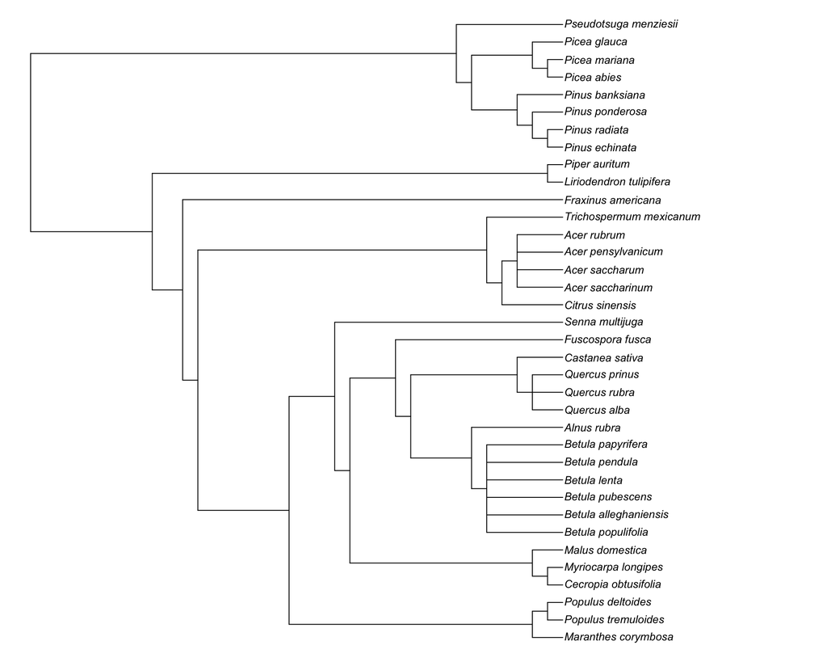

```r
plot(tree, cex=.8, label.offset =.1, no.margin = TRUE)
```

```r
tree$tip.label <- gsub("_"," ", tree$tip.label) #get rid of underscores
# tree$node.label <- NULL #delete node labels

#check the tree match
# intersect(as.character(tree$tip.label), species_Curtis1998) #matches - they are contained in the tree and our species list
setdiff(species_Curtis1998, as.character(tree$tip.label)) #1 mismatch - these are only in species_Curtis1998
```

```
## [1] "Nothofagus fusca"
```

```r
setdiff(as.character(tree$tip.label), species_Curtis1998) #1 mismatch - these are only in tree$tip.label
```

```
## [1] "Fuscospora fusca"
```

```r
#amend the tip labels on the tree to match the species names from Curtis1998
tree$tip.label <- gsub("Fuscospora fusca", "Nothofagus fusca", tree$tip.label) #replace the tip label back with our species name

#check the tree match again
# intersect(as.character(tree$tip.label), species_Curtis1998) #matches - they are contained in the tree and our species list
setdiff(species_Curtis1998, as.character(tree$tip.label)) #0 mismatches
```

```
## character(0)
```

```r
setdiff(as.character(tree$tip.label), species_Curtis1998) #0 mismatches
```

```
## character(0)
```

```r
# write.tree(tree, file="../data/tree_curtis1998.tre") #save the tree in Newick format, if needed
# read.tree(file="../data/tree_curtis1998.tre") #if you need to read it
```

Check if our tree is binary (you can see in the plot that there are a few polytomies).

```r
is.binary.tree(tree) #FALSE (i.e. there are polytomies)
```

```
## [1] FALSE
```

```r
# is.ultrametric(tree) #the tree has no branch lengths, so cant be checked
#write.tree(tree, file="../data/tree_curtis1998.tre") #save the tree
# tree <- read.tree(file="../data/tree_curtis1998.tre") #if you need to read it
```

```r
set.seed(111) #making it replicable
tree_random <- multi2di(tree,random=TRUE)
is.binary.tree(tree_random) #TRUE
```

```
## [1] TRUE
```

```r
#write.tree(tree_random, file="../data/tree_curtis1998_random.tre") #save the tree
# tree_random <- read.tree(file="../data/tree_curtis1998_random.tre") #if you need to read it
```

Plot the tree now - with randomly resolved polytomies.

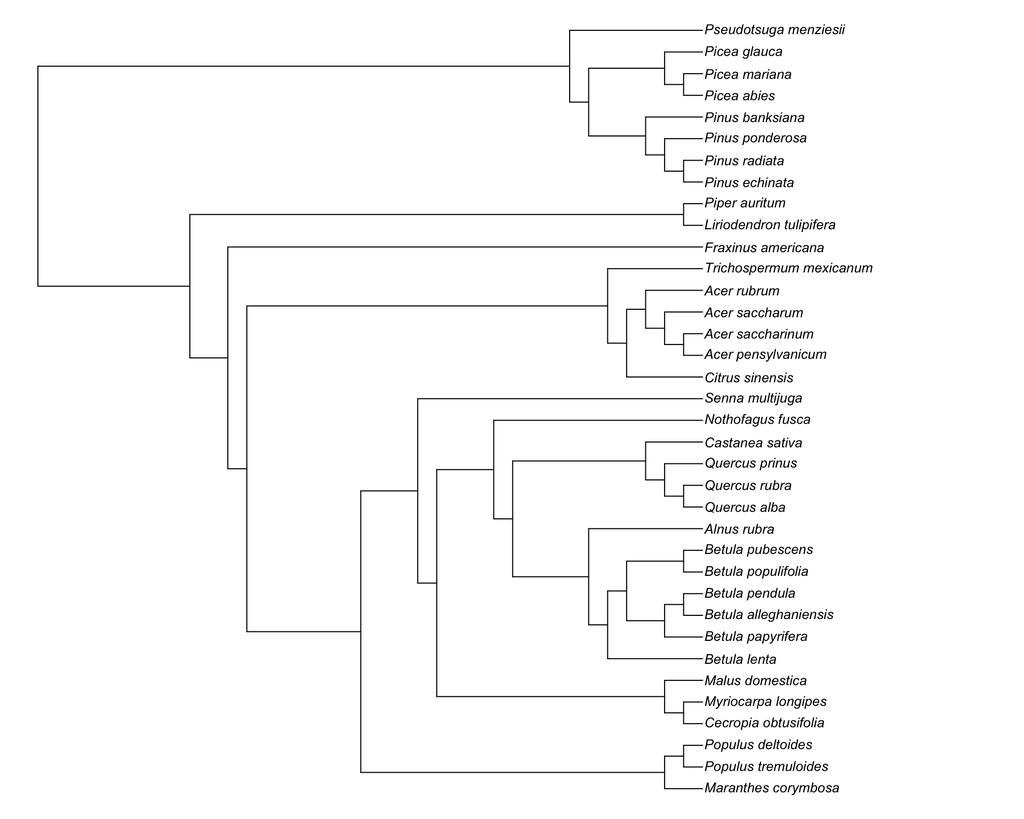

```r
plot(tree_random, cex=.8, label.offset =.1, no.margin = TRUE)
```

Other, more involved approaches for resolving polytomies:

1. Resolving one or more multifurcations (i.e. polytomies) in all possible ways: http://blog.phytools.org/2016/08/resolving-one-or-more-multifurcations.html
2. Package for resolving by known discrete characters of the species_Curtis1998: https://www.rdocumentation.org/packages/paleotree/versions/3.1.3/topics/resolveTreeChar
3. Resolving manually by using information from known more specialized published phylogeny without polytomies (see next exercise for how to try to find these).

### EXAMPLE 4 - using *treebase* package

We can try to find some relevant trees using Treebase database and *treebase* package (Treebase package tutorial: https://cran.r-project.org/web/packages/treebase/vignettes/vignette.html and https://www.carlboettiger.info/2011/05/16/treebase-in-r-a-first-tutorial.html).

As an exercise, we will try to find more resolved phylogeny for the four species from genus Acer that were included in Curtis1998 from R. However, Treebase sometimes may not connect or run the search string correctly. You can try search Treebase directly at www.treebase.org, but sometimes its quite slow or not working. So, just in case we also provide the full tree files downloaded from there, which can be used in this exercise. To see more easily what is in the Treebase database, we first try to find a tree via Treebase website search - you can go to https://treebase.org/treebase-web/search/studySearch.html and enter “Acer” in the search box, then select “Title” from the drop-down menu next to it, press “Search” button.

There are 57 studies, but most of them were selected because they contain word “spaACER” (we are a bit unlucky with the taxon name). There are a few study titles that mention Acer which potentially may contain relevant trees and species: S2155, S2157 and S342. You can tick boxes next to them and then press button “Discard unchecked items” at the bottom of the window. Now, if you select just one of the remaining 3 studies and then go to the Taxa tab, you will see the list of taxa associated with a given study.

In this exercise we will use study S342 Ackerly D., Donoghue M.J. 1998, so check the box next to it and then “Discard unchecked items” button at the bottom. Then, go to the “Trees”" tab where you will see 2 trees from this study. We pick Tr418 (consensus, i.e. made from collapsing multiple possible similar single trees). You can download it as a Nexus file by clicking the icons on the right. Note: you can also start the search from Tree tab, by searching tree titles and then look at the studies from which these trees are, or even start the search for the most obscure species in the Species tab - sometimes these approaches may work better.

Now we will try to do similar work from R. First, we create a custom search string with our four Acer species names from Curtis1998 data set.

```r
Acer4sp <- species_Curtis1998[grep("Acer ", species_Curtis1998)]
Acer4sp #you should get "Acer rubrum"        "Acer saccharinum"   "Acer pensylvanicum" "Acer saccharum"
```

```
## [1] "Acer rubrum"        "Acer saccharinum"   "Acer pensylvanicum"
## [4] "Acer saccharum"
```

```r
Acer4sp <- gsub(" ","_", Acer4sp) #put underscores back in the names
Acer4sp_string <- paste(Acer4sp, sep = "", collapse = ' and ')
Acer4sp_string #you should get "Acer_rubrum and Acer_saccharinum and Acer_pensylvanicum and Acer_saccharum"
```

```
## [1] "Acer_rubrum and Acer_saccharinum and Acer_pensylvanicum and Acer_saccharum"
```

Run the treebase search - get max 50 trees that contain exactly these four species names.

```r
#this is an example of how to search for a single species:
# Acer <- search_treebase("Acer_saccharinumc", by="taxon", max_trees=10) #example of using with a single species name - note different commas than in the tutorial and the underscores!

Acer_treebase <- search_treebase(Acer4sp_string, by=c("taxon","taxon","taxon","taxon"), max_trees=50, exact_match = TRUE, only_metadata = TRUE) #note different commas than in the treebase tutorial!
```

```
## http://purl.org/phylo/treebase/phylows/taxon/find?query=tb.title.taxon==Acer_rubrum%20and%20tb.title.taxon=Acer_saccharinum%20and%20tb.title.taxon=Acer_pensylvanicum%20and%20tb.title.taxon=Acer_saccharum&format=rss1&recordSchema=tree
```

```
## Query resolved, looking at each matching resource...
```

```
## 49 resources found matching query
```

```r
# Acer_treebase #list of 49 meta-data results of our search
# str(Acer_treebase) #some more info can be seen here

#Unfortunately the functions in treebase that are supposed to fetch metadata for the trees dont seem to work (show_metadata, metadata - if you get them workinng please let me know).
#For easier viewing we will put these inn a data frame (note that multiple tree IDs can come from the same study).
t(data.frame(matrix(unlist(Acer_treebase), nrow=6, byrow=F), row.names = c("S.id", "Tr.id", "type", "kind", "quality", "ntax"))) #note the study IDs that you are using - you can find these on Treebase
```

```
##     S.id    Tr.id    type        kind           quality   ntax
## X1  "10580" "9487"   "Single"    "Species Tree" "Unrated" "243"
## X2  "18945" "94055"  "Consensus" "Species Tree" "Unrated" "270"
## X3  "10580" "9500"   "Single"    "Species Tree" "Unrated" "243"
## X4  "19364" "96391"  NA          NA             NA        "31"
## X5  "19364" "96395"  "Single"    "Species Tree" "Unrated" "34"
## X6  "2155"  "5297"   "Single"    "Species Tree" "Unrated" "340"
## X7  "19364" "96392"  "Single"    "Species Tree" "Unrated" "31"
## X8  "10580" "9503"   "Single"    "Species Tree" "Unrated" "243"
## X9  "10580" "9494"   "Single"    "Species Tree" "Unrated" "243"
## X10 "2157"  "5305"   "Consensus" "Species Tree" "Unrated" "53"
## X11 "10580" "9511"   "Single"    "Species Tree" "Unrated" "243"
## X12 "10580" "9502"   "Single"    "Species Tree" "Unrated" "243"
## X13 "10580" "9508"   "Single"    "Species Tree" "Unrated" "243"
## X14 "10580" "9485"   "Single"    "Species Tree" "Unrated" "243"
## X15 "2155"  "5296"   "Consensus" "Species Tree" "Unrated" "105"
## X16 "10580" "9501"   "Single"    "Species Tree" "Unrated" "243"
## X17 "10580" "9505"   "Single"    "Species Tree" "Unrated" "243"
## X18 "10580" "9514"   "Single"    "Species Tree" "Unrated" "243"
## X19 "10580" "9492"   "Single"    "Species Tree" "Unrated" "243"
## X20 "10580" "9491"   "Single"    "Species Tree" "Unrated" "243"
## X21 "10580" "9517"   "Single"    "Species Tree" "Unrated" "243"
## X22 "10580" "9489"   "Single"    "Species Tree" "Unrated" "243"
## X23 "10580" "9512"   "Single"    "Species Tree" "Unrated" "243"
## X24 "2155"  "5299"   "Single"    "Species Tree" "Unrated" "340"
## X25 "10580" "9510"   "Single"    "Species Tree" "Unrated" "243"
## X26 "10580" "9509"   "Single"    "Species Tree" "Unrated" "243"
## X27 "10580" "9486"   "Single"    "Species Tree" "Unrated" "243"
## X28 "10580" "9518"   "Single"    "Species Tree" "Unrated" "243"
## X29 "342"   "418"    "Consensus" "Species Tree" "Unrated" "37"
## X30 "10580" "9504"   "Single"    "Species Tree" "Unrated" "243"
## X31 "19364" "96394"  NA          NA             NA        "33"
## X32 "10580" "9488"   "Single"    "Species Tree" "Unrated" "243"
## X33 "10580" "9507"   "Single"    "Species Tree" "Unrated" "243"
## X34 "10580" "9493"   "Single"    "Species Tree" "Unrated" "243"
## X35 "10580" "9497"   "Single"    "Species Tree" "Unrated" "243"
## X36 "10580" "9490"   "Single"    "Species Tree" "Unrated" "243"
## X37 "2157"  "5304"   "Single"    "Species Tree" "Unrated" "70"
## X38 "22057" "113123" "Consensus" "Species Tree" "Unrated" "654"
## X39 "19364" "96389"  "Single"    "Species Tree" "Unrated" "30"
## X40 "19364" "96390"  "Single"    "Species Tree" "Unrated" "26"
## X41 "10580" "9496"   "Single"    "Species Tree" "Unrated" "243"
## X42 "10580" "9499"   "Single"    "Species Tree" "Unrated" "243"
## X43 "10580" "9515"   "Single"    "Species Tree" "Unrated" "243"
## X44 "10580" "9516"   "Single"    "Species Tree" "Unrated" "243"
## X45 "10580" "9513"   "Single"    "Species Tree" "Unrated" "243"
## X46 "19364" "96393"  "Single"    "Species Tree" "Unrated" "34"
## X47 "10580" "9495"   "Single"    "Species Tree" "Unrated" "243"
## X48 "10580" "9506"   "Single"    "Species Tree" "Unrated" "243"
## X49 "10580" "9498"   "Single"    "Species Tree" "Unrated" "243"
## X50 NA      NA       NA          NA             NA        NA
```

There are multiple trees available from several studies. Note that the lost of found results includes the tree 418 from study 342 we already identified in our Treebase website search.  
So, we will request specifically tree Tr418 from Study S342 (the one we already found via Treebase website search; Ackerly D., Donoghue M.J. 1998 Leaf size, sapling allometry, and Corner’s rules: phylogeny and correlated evolution in maples (Acer). American Naturalist). It may take a moment, depending on the size of the tree. You can try requesting different trees later and comparing whether you get different sub-trees after pruning.

```r
Acers_tree <- search_treebase("418", by="id.tree", exact_match = TRUE) #returns a single tree in a list
```

```
## http://purl.org/phylo/treebase/phylows/tree/find?query=tb.identifier.tree==418&format=rss1&recordSchema=tree
```

```
## Query resolved, looking at each matching resource...
```

```
## 1 resources found matching query
```

```
## Attempting try 1
```

```
## Looking for nexus files...
```

```
## Tree read in successfully
```

```
## dropped 0 objects
```

```r
Acers_tree <- Acers_tree[[1]] #extract the tree from the list
```

If downloading from R treebase did not work, upload tree saved in a file:

```r
Acers_tree <- read.nexus(file = "../data/T418.nex") #read Nexus tree file
```

Plot the Acers tree from Treebase - looks good.

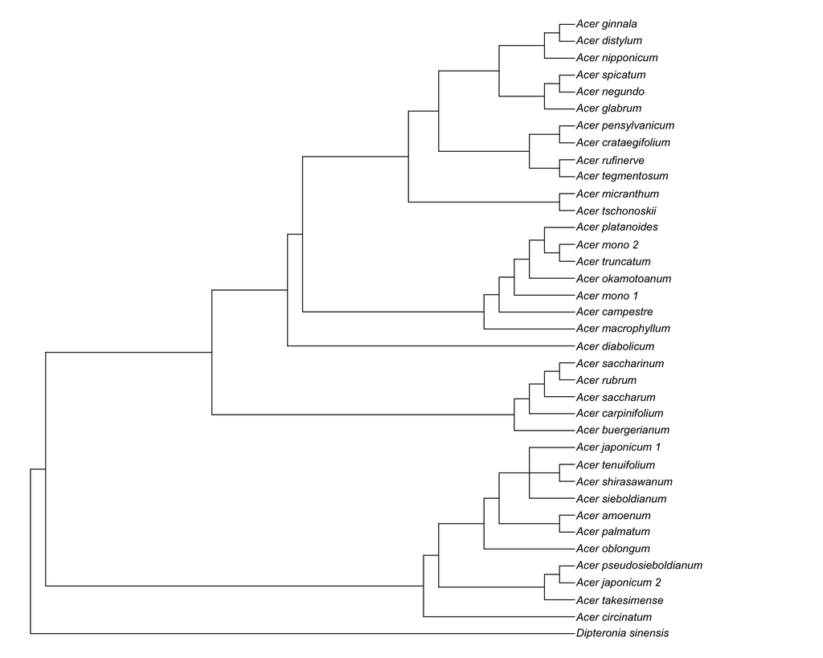

```r
plot(Acers_tree, cex=.8, label.offset =.1, no.margin = TRUE)
```

Prune this tree to our four species.

```r
#Prune Acers_tree to a list of four taxa from our list
Acers4sp_tree <- drop.tip(Acers_tree, Acers_tree$tip.label[-match(Acer4sp, Acers_tree$tip.label)])
```

Plot the pruned tree.

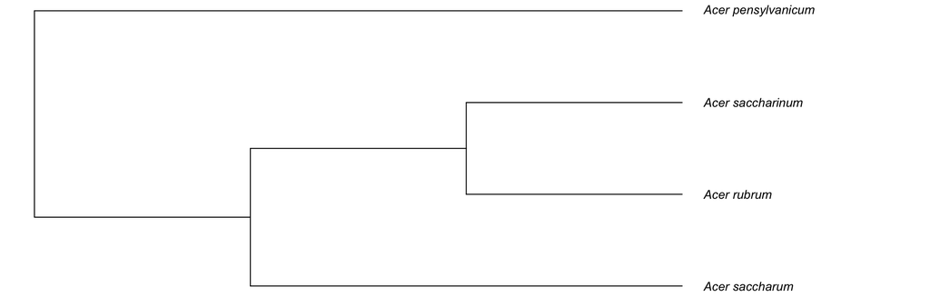

```r
plot(Acers4sp_tree, cex=.8, label.offset =.1, no.margin = TRUE)
```

Final checks.

```r
###check the overlap between species name from the data fila nad the tree file
intersect(as.character(Acers4sp_tree$tip.label), Acer4sp) # all matching
```

```
## [1] "Acer_saccharum"     "Acer_rubrum"        "Acer_saccharinum"
## [4] "Acer_pensylvanicum"
```

```r
setdiff(Acer4sp, as.character(Acers4sp_tree$tip.label)) #no mismatches
```

```
## character(0)
```

```r
is.binary.tree(Acers4sp_tree) #TRUE
```

```
## [1] TRUE
```

We can graft this tree on the Curtis1998 tree to non-randomly resolve polytomy for genus Acer.  
**Note:** when grafting you lose branch lengths on the original tree, if present.

We first need to prune given branch from the main tree to remove all but one species affected by polytomy. Then we can replace this species with the resolved sub-tree (Acers4sp_tree):

```r
tree_pruned <- drop.tip(tree, c("Acer saccharum", "Acer rubrum", "Acer saccharinum")) #prune 3 species
tree_grafted <- bind.tree(tree_pruned, Acers4sp_tree, where=which(tree_pruned$tip.label=="Acer pensylvanicum")) #graft 3 species to the remaining Acer species
```

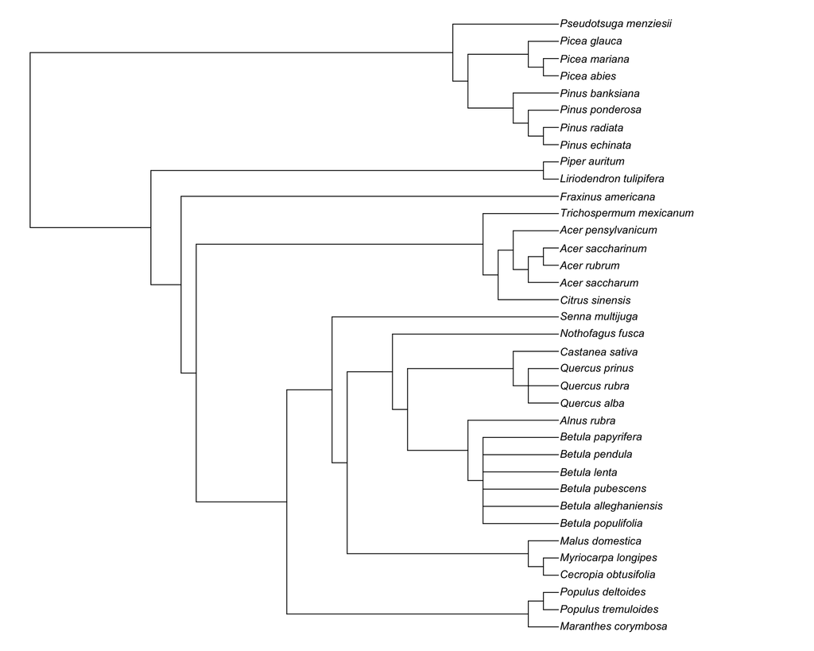

```r
plot(tree_grafted, cex=.8, label.offset =.1, no.margin = TRUE)
```

### EXAMPLE 5 - try it yourself - rotl

Use *rotl* to create a tree for the bunch of reptiles.  
**Remember**: Make sure that species names match exactly tree tip labels.

Here is the species list:

```r
myspecies2 <- c("Gekko japonicus", "Geochelone sulcata", "Gopherus agassizii", "Gopherus polyphemus", "Graptemys ouachitensis", "Graptemys pseudogeographica", "Hemidactylus bowringii", "Heterodon platirhinos", "Heteronotia binoei", "Iberolacerta cyeni", "Lacerta schreiberi", "Lampropholis delicata", "Lampropholis guichenoti", "Liasis fuscus")
```

### EXAMPLE 6 - try it yourself- treebase

Use *treebase* to create a tree for the three Quercus species from dat.Curtis1998. You can try to graft them on the Curtis 1998 tree.

**Hint**: Quercus prinus is also called Quercus montana (https://en.wikipedia.org/wiki/Quercus_montana).  
Once you substitute, all three species can be found on Tree 113123 of Study 22057, and also in several other studies and trees.

Here is the species list:

```r
Quercus3sp <- species_Curtis1998[grep("Quercus ", species_Curtis1998)]
```

### DISCUSSION

W hope you learn a few tricks on how to make phylogenetic-like trees of species that can be used in meta-analytic models. There is much more to learn, especially dealing with missing or rare species names, grafting trees together, resolving polytomies, plotting cool trees etc. In some cases getting “perfect” tree may not be possible - but phylogenies are always just estimates of the species relationships, and as long as you get the key features right, the tree will be OK, and so your analyses (in most cases).

## OTHER RESOURCES

Search for help: discussion list R-sig-phylo archive at http://www.mail-archive.com/r-sig-phylo@r-project.org/

Tree manipulation in R: http://www.r-phylo.org/wiki/HowTo/DataTreeManipulation

R-based GUI tree viewer: https://klash.shinyapps.io/shinyTreeViewer